# Loan Data From Prosper

## by *Anderson Abi-A Shoh Chama*

- Introduction
- Data Wrangling, Assessing, Cleaning
- Univariate Exploration
- Bivariate Exploration
- Multivariate Exploration
- Conclusions

## Introduction

In this project, I will explore Loan dataset from Prosper, which contains 113,937 rows and 81 columns. I will pick some of the variables that are related to Default to analyze. Firstly, some data wrangling and cleaning, and then on to EDA with different types of charts to explore relationships between/among variables, and hopefully get significant results from my research.

<a id = 'wrangling'></a>

## Data Wrangling, Assessing, & Cleaning

### Data Wrangling

```python
# import all packages and set plots to be embedded inline
import numpy as np
import pandas as pd
import matplotlib.pyplot as plt
import seaborn as sb
import warnings
warnings.filterwarnings('ignore')
pd.set_option('display.max_columns', None)
%matplotlib inline
```

```python
# Loading the datasets and assessing.
loan = pd.read_csv("prosperLoanData.csv")
loan.head()
```

|  | ListingKey | ListingNumber | ListingCreationDate | CreditGrade | Term | LoanStatus | ClosedDate | BorrowerAPR | BorrowerRate | LenderYield | EstimatedEffectiveYield | EstimatedLoss | EstimatedReturn | ProsperRating (numeric) | ProsperRating (Alpha) | ProsperScore | ListingCategory (numeric) | BorrowerState | Occupation | EmploymentStatus | EmploymentStatusDuration | IsBorrowerHomeowner | CurrentlyInGroup | GroupKey | DateCreditPulled | CreditScoreRangeLower | CreditScoreRangeUpper | FirstRecordedCreditLine | CurrentCreditLines | … |
| --- | --- | --- | --- | --- | --- | --- | --- | --- | --- | --- | --- | --- | --- | --- | --- | --- | --- | --- | --- | --- | --- | --- | --- | --- | --- | --- | --- | --- | --- | --- |
| 0 | 1021339766868145413AB3B | 193129 | 2007-08-26 19:09:29.263000000 | C | 36 | Completed | 2009-08-14 00:00:00 | 0.16516 | 0.1580 | 0.1380 | NaN | NaN | NaN | NaN | NaN | NaN | 0 | CO | Other | Self-employed | 2.0 | True | True | NaN | 2007-08-26 18:41:46.780000000 | 640.0 | 659.0 | 2001-10-11 00:00:00 | 5.0 | … |
| 1 | 10273602499503308B223C1 | 1209647 | 2014-02-27 08:28:07.900000000 | NaN | 36 | Current | NaN | 0.12016 | 0.0920 | 0.0820 | 0.07960 | 0.0249 | 0.05470 | 6.0 | A | 7.0 | 2 | CO | Professional | Employed | 44.0 | False | False | NaN | 2014-02-27 08:28:14 | 680.0 | 699.0 | 1996-03-18 00:00:00 | 14.0 | … |
| 2 | 0EE9337825851032864889A | 81716 | 2007-01-05 15:00:47.090000000 | HR | 36 | Completed | 2009-12-17 00:00:00 | 0.28269 | 0.2750 | 0.2400 | NaN | NaN | NaN | NaN | NaN | NaN | 0 | GA | Other | Not available | NaN | False | True | 783C3371218786870A73D20 | 2007-01-02 14:09:10.060000000 | 480.0 | 499.0 | 2002-07-27 00:00:00 | NaN | … |
| 3 | 0EF5356002482715299901A | 658116 | 2012-10-22 11:02:35.010000000 | NaN | 36 | Current | NaN | 0.12528 | 0.0974 | 0.0874 | 0.08490 | 0.0249 | 0.06000 | 6.0 | A | 9.0 | 16 | GA | Skilled Labor | Employed | 113.0 | True | False | NaN | 2012-10-22 11:02:32 | 800.0 | 819.0 | 1983-02-28 00:00:00 | 5.0 | … |
| 4 | 0F023589499656230C5E3E2 | 909464 | 2013-09-14 18:38:39.097000000 | NaN | 36 | Current | NaN | 0.24614 | 0.2085 | 0.1985 | 0.18316 | 0.0925 | 0.09066 | 3.0 | D | 4.0 | 2 | MN | Executive | Employed | 44.0 | True | False | NaN | 2013-09-14 18:38:44 | 680.0 | 699.0 | 2004-02-20 00:00:00 | 19.0 | … |

```python
# Overview of the dataset.
print(loan.shape)
print(loan.info())
```

```
(113937, 81)
<class 'pandas.core.frame.DataFrame'>
RangeIndex: 113937 entries, 0 to 113936
Data columns (total 81 columns):
ListingKey                             113937 non-null object
ListingNumber                          113937 non-null int64
ListingCreationDate                    113937 non-null object
CreditGrade                            28953 non-null object
Term                                   113937 non-null int64
LoanStatus                             113937 non-null object
ClosedDate                             55089 non-null object
BorrowerAPR                            113912 non-null float64
BorrowerRate                           113937 non-null float64
LenderYield                            113937 non-null float64
EstimatedEffectiveYield                84853 non-null float64
EstimatedLoss                          84853 non-null float64
EstimatedReturn                        84853 non-null float64
ProsperRating (numeric)                84853 non-null float64
ProsperRating (Alpha)                  84853 non-null object
ProsperScore                           84853 non-null float64
ListingCategory (numeric)              113937 non-null int64
BorrowerState                          108422 non-null object
Occupation                             110349 non-null object
EmploymentStatus                       111682 non-null object
EmploymentStatusDuration               106312 non-null float64
IsBorrowerHomeowner                    113937 non-null bool
CurrentlyInGroup                       113937 non-null bool
GroupKey                               13341 non-null object
DateCreditPulled                       113937 non-null object
CreditScoreRangeLower                  113346 non-null float64
CreditScoreRangeUpper                  113346 non-null float64
FirstRecordedCreditLine                113240 non-null object
CurrentCreditLines                     106333 non-null float64
OpenCreditLines                        106333 non-null float64
TotalCreditLinespast7years             113240 non-null float64
OpenRevolvingAccounts                  113937 non-null int64
OpenRevolvingMonthlyPayment            113937 non-null float64
InquiriesLast6Months                   113240 non-null float64
TotalInquiries                         112778 non-null float64
CurrentDelinquencies                   113240 non-null float64
```

[output cut: 33 more lines]

```
LP_CustomerPrincipalPayments           113937 non-null float64
LP_InterestandFees                     113937 non-null float64
LP_ServiceFees                         113937 non-null float64
LP_CollectionFees                      113937 non-null float64
LP_GrossPrincipalLoss                  113937 non-null float64
LP_NetPrincipalLoss                    113937 non-null float64
LP_NonPrincipalRecoverypayments        113937 non-null float64
PercentFunded                          113937 non-null float64
Recommendations                        113937 non-null int64
InvestmentFromFriendsCount             113937 non-null int64
InvestmentFromFriendsAmount            113937 non-null float64
Investors                              113937 non-null int64
dtypes: bool(3), float64(50), int64(11), object(17)
memory usage: 68.1+ MB
None
```

```python
# descriptive statistics for numeric variables
print(loan.describe())
```

```
       ListingNumber           Term    BorrowerAPR   BorrowerRate  \
count   1.139370e+05  113937.000000  113912.000000  113937.000000
mean    6.278857e+05      40.830248       0.218828       0.192764
std     3.280762e+05      10.436212       0.080364       0.074818
min     4.000000e+00      12.000000       0.006530       0.000000
25%     4.009190e+05      36.000000       0.156290       0.134000
50%     6.005540e+05      36.000000       0.209760       0.184000
75%     8.926340e+05      36.000000       0.283810       0.250000
max     1.255725e+06      60.000000       0.512290       0.497500

         LenderYield  EstimatedEffectiveYield  EstimatedLoss  EstimatedReturn  \
count  113937.000000             84853.000000   84853.000000     84853.000000
mean        0.182701                 0.168661       0.080306         0.096068
std         0.074516                 0.068467       0.046764         0.030403
min        -0.010000                -0.182700       0.004900        -0.182700
25%         0.124200                 0.115670       0.042400         0.074080
50%         0.173000                 0.161500       0.072400         0.091700
75%         0.240000                 0.224300       0.112000         0.116600
max         0.492500                 0.319900       0.366000         0.283700

       ProsperRating (numeric)  ProsperScore  ListingCategory (numeric)  \
count             84853.000000  84853.000000              113937.000000
mean                  4.072243      5.950067                   2.774209
std                   1.673227      2.376501                   3.996797
min                   1.000000      1.000000                   0.000000
25%                   3.000000      4.000000                   1.000000
50%                   4.000000      6.000000                   1.000000
75%                   5.000000      8.000000                   3.000000
max                   7.000000     11.000000                  20.000000

       EmploymentStatusDuration  CreditScoreRangeLower  CreditScoreRangeUpper  \
count             106312.000000          113346.000000          113346.000000
mean                  96.071582             685.567731             704.567731
std                   94.480605              66.458275              66.458275
min                    0.000000               0.000000              19.000000
25%                   26.000000             660.000000             679.000000
50%                   67.000000             680.000000             699.000000
75%                  137.000000             720.000000             739.000000
max                  755.000000             880.000000             899.000000

```

[output cut: 174 more lines]

```
min           0.000000                    0.000000
25%           0.000000                    0.000000
50%           0.000000                    0.000000
75%           0.000000                    0.000000
max          39.000000                   33.000000

       InvestmentFromFriendsAmount      Investors
count                113937.000000  113937.000000
mean                     16.550751      80.475228
std                     294.545422     103.239020
min                       0.000000       1.000000
25%                       0.000000       2.000000
50%                       0.000000      44.000000
75%                       0.000000     115.000000
max                   25000.000000    1189.000000
```

```python
loan[loan.duplicated()]
```

|  | ListingKey | ListingNumber | ListingCreationDate | CreditGrade | Term | LoanStatus | ClosedDate | BorrowerAPR | BorrowerRate | LenderYield | EstimatedEffectiveYield | EstimatedLoss | EstimatedReturn | ProsperRating (numeric) | ProsperRating (Alpha) | ProsperScore | ListingCategory (numeric) | BorrowerState | Occupation | EmploymentStatus | EmploymentStatusDuration | IsBorrowerHomeowner | CurrentlyInGroup | GroupKey | DateCreditPulled | CreditScoreRangeLower | CreditScoreRangeUpper | FirstRecordedCreditLine | CurrentCreditLines | … |
| --- | --- | --- | --- | --- | --- | --- | --- | --- | --- | --- | --- | --- | --- | --- | --- | --- | --- | --- | --- | --- | --- | --- | --- | --- | --- | --- | --- | --- | --- | --- |

> We observed the presence of zero duplicated rows

#### What is the structure of your dataset?

> There are 113,937 entries in the dataset with 81 features. We have numeric variables, categorical variables, boolean and date. Variables like ProsperRating (Alpha) and IncomeRange can be ordered factor variables with the following levels:

> ProsperRating (Alpha): AA, A, B, C, D, E, HR (best to worth)

> IncomeRange: Not employed, \$0, \\$1-\$24,999, \\$25,000-\$49,999, \\$50,000-\$74,999, \\$75,000-\$99,999, \\$100,000+

> Lot of null values found in some variables, such as variables prosperrating and prosperscore, which I'll need to take care of later.

> Some variables are not needed for my research and will have to be truncated, such as listingkey, listingnumber, of other identifiers.

#### What is the main factor of interest in your dataset?

> My point of interest is finding out what factors are most suitable for knowing whether a loan would fail or not, which is the LoanStatus variable.

#### What other factors do you think will help support your investigation into your main factor?

> I expect that variables related to borrowers' personal situation would have effect on default, such as EmploymentStatus, CreditScoreRangeLower/Upper, DelinquenciesLast7Years, IncomeRange, etc. Because a borrower's financial status will have huge effect on their loan payment.

### Data Assessing and Cleaning

> Time to clean!! I will be dropping the columns I won't need for the research, and then handle the null values after which, I will take care of the float and int variables.

```python
# Start by creating a copy of the original dataset. We use that for the analysis
loan_clean = loan.copy()
```

```python
# Change column names to lowercase and replace space with underscore for convenience.
loan_clean.columns = map(str.lower, loan_clean.columns)
loan_clean.columns = loan_clean.columns.str.replace(' ', '_')
```

```python
# Remove columns not needed for my research analysis.
loan_clean.drop(columns = ['listingkey', 'listingnumber', 'groupkey', 'loankey', 'loannumber', 'memberkey'], axis=1, inplace = True)
```

```python
# Handle the null values.
categorical_columns = loan_clean.select_dtypes(include = 'object').columns
loan_clean[categorical_columns] = loan_clean[categorical_columns].fillna('unknown')
loan_clean.select_dtypes(include = 'object').isnull().sum()
```

```
listingcreationdate        0
creditgrade                0
loanstatus                 0
closeddate                 0
prosperrating_(alpha)      0
borrowerstate              0
occupation                 0
employmentstatus           0
datecreditpulled           0
firstrecordedcreditline    0
incomerange                0
loanoriginationdate        0
loanoriginationquarter     0
dtype: int64
```

```python
# Since APR = Interest rate + fee, and borrowrate column does not have null values, so I'll remove borrowerapr column
loan_clean.drop(columns = 'borrowerapr', inplace = True)
```

```python
# Estimatedeffectiveyield, estimatedloss & estimatedreturn all have null values,
# and since I won't use for my analysis, I'll drop them now.
loan_clean.drop(columns = ['estimatedeffectiveyield', 'estimatedloss', 'estimatedreturn'], inplace = True)
```

```python
# I will drop prosperrating_(numeric), and prosperscore.
loan_clean.drop(columns = ['prosperrating_(numeric)', 'prosperscore'], inplace = True)
```

```python
# Variables employmentstatusduration, creditscorerangelower, creditscorerangeupper, currentcreditlines,
# opencreditlines, totalcreditlinespast7years, currentdelinquencies, amountdelinquent, delinquencieslast7years,
# they all have some small amount of null values, so I'll drop the rows with null values.
loan_clean.dropna(subset = ['employmentstatusduration', 'creditscorerangelower', 'creditscorerangeupper', \
                            'currentcreditlines', 'opencreditlines', 'totalcreditlinespast7years', 'currentdelinquencies', \
                            'amountdelinquent', 'delinquencieslast7years'], inplace = True)
```

```python
# Variable debttoincomeratio which is one important variable in this dataset has many null values in that column.
loan_clean[loan_clean['debttoincomeratio'].isnull()][:5]
```

|  | listingcreationdate | creditgrade | term | loanstatus | closeddate | borrowerrate | lenderyield | prosperrating_(alpha) | listingcategory_(numeric) | borrowerstate | occupation | employmentstatus | employmentstatusduration | isborrowerhomeowner | currentlyingroup | datecreditpulled | creditscorerangelower | creditscorerangeupper | firstrecordedcreditline | currentcreditlines | opencreditlines | totalcreditlinespast7years | openrevolvingaccounts | openrevolvingmonthlypayment | inquirieslast6months | totalinquiries | currentdelinquencies | amountdelinquent | delinquencieslast7years | … |
| --- | --- | --- | --- | --- | --- | --- | --- | --- | --- | --- | --- | --- | --- | --- | --- | --- | --- | --- | --- | --- | --- | --- | --- | --- | --- | --- | --- | --- | --- | --- |
| 40 | 2014-01-27 12:02:57.523000000 | unknown | 60 | Current | unknown | 0.1725 | 0.1625 | C | 1 | WA | Other | Self-employed | 276.0 | False | False | 2014-01-25 10:47:25 | 680.0 | 699.0 | 1985-12-20 00:00:00 | 10.0 | 9.0 | 28.0 | 10 | 1233.0 | 0.0 | 2.0 | 0.0 | 0.0 | 0.0 | … |
| 69 | 2014-01-25 12:07:54.537000000 | unknown | 60 | Current | unknown | 0.1139 | 0.1039 | A | 1 | IL | Investor | Self-employed | 12.0 | True | True | 2014-01-25 11:51:41 | 700.0 | 719.0 | 1995-08-01 00:00:00 | 5.0 | 5.0 | 21.0 | 3 | 373.0 | 0.0 | 2.0 | 0.0 | 0.0 | 0.0 | … |
| 78 | 2008-06-29 23:23:40.157000000 | A | 36 | Chargedoff | 2009-04-09 00:00:00 | 0.1700 | 0.1600 | unknown | 3 | CA | Realtor | Full-time | 68.0 | True | False | 2008-06-29 23:13:04.860000000 | 720.0 | 739.0 | 1995-11-29 00:00:00 | 14.0 | 14.0 | 26.0 | 9 | 962.0 | 4.0 | 11.0 | 0.0 | 0.0 | 0.0 | … |
| 100 | 2013-01-25 11:48:26.040000000 | unknown | 36 | Chargedoff | 2013-08-30 00:00:00 | 0.3134 | 0.3034 | HR | 13 | CA | Other | Not employed | 12.0 | False | False | 2013-01-11 12:10:13 | 720.0 | 739.0 | 2000-09-10 00:00:00 | 3.0 | 3.0 | 10.0 | 3 | 56.0 | 0.0 | 2.0 | 0.0 | 0.0 | 0.0 | … |
| 103 | 2012-04-17 11:58:52.270000000 | unknown | 36 | Chargedoff | 2013-03-22 00:00:00 | 0.2287 | 0.2187 | D | 3 | CO | Truck Driver | Self-employed | 29.0 | True | False | 2012-04-17 11:58:46 | 680.0 | 699.0 | 1993-10-26 00:00:00 | 9.0 | 7.0 | 21.0 | 1 | 699.0 | 0.0 | 0.0 | 0.0 | 0.0 | 0.0 | … |

```python
# We calculate debt-income ratio using monthlyloanpayment and statedmonthlyincome columns
loan_clean['debttoincomeratio'].fillna(loan_clean['monthlyloanpayment'] / loan_clean['statedmonthlyincome'], inplace = True)
```

```python
# Add 1 to statedmonthlyincome to calculate debttoincomeratio when statedmonthlyincome equals 0.
loan_clean['debttoincomeratio'].replace(np.inf, np.nan, inplace = True)
loan_clean['debttoincomeratio'].fillna(loan_clean['monthlyloanpayment'] / (loan_clean['statedmonthlyincome'] + 1), inplace = True)
```

```python
# Change null values of totalprosperloans, prosperpaymentslessthanonemonthlate, ontimeprosperpayments, prosperprincipalborrowed,
# prosperpaymentsonemonthpluslate, totalprosperpaymentsbilled, and prosperprincipaloutstanding to 0, given that
# these values will be null if the borrower had no prior loans.
columns = ['totalprosperloans', 'totalprosperpaymentsbilled', 'ontimeprosperpayments', 'prosperpaymentslessthanonemonthlate',\
            'prosperpaymentsonemonthpluslate', 'prosperprincipalborrowed', 'prosperprincipaloutstanding']
for fac in columns:
    loan_clean[fac].fillna(0, inplace = True)
```

```python
# Dropping scorexchangeattimeoflisting, LP_, loanfirstdefaultedcyclenumber, and recommendations columns which I do not need.
loan_clean.drop(columns = ['scorexchangeattimeoflisting', 'lp_customerprincipalpayments','loanfirstdefaultedcyclenumber', \
                          'lp_customerpayments', 'lp_interestandfees', 'lp_netprincipalloss', 'lp_nonprincipalrecoverypayments',\
                          'lp_grossprincipalloss', 'lp_servicefees', 'lp_collectionfees'], inplace = True)
```

```python
loan_clean.info()
```

```
<class 'pandas.core.frame.DataFrame'>
Int64Index: 106290 entries, 0 to 113936
Data columns (total 59 columns):
listingcreationdate                    106290 non-null object
creditgrade                            106290 non-null object
term                                   106290 non-null int64
loanstatus                             106290 non-null object
closeddate                             106290 non-null object
borrowerrate                           106290 non-null float64
lenderyield                            106290 non-null float64
prosperrating_(alpha)                  106290 non-null object
listingcategory_(numeric)              106290 non-null int64
borrowerstate                          106290 non-null object
occupation                             106290 non-null object
employmentstatus                       106290 non-null object
employmentstatusduration               106290 non-null float64
isborrowerhomeowner                    106290 non-null bool
currentlyingroup                       106290 non-null bool
datecreditpulled                       106290 non-null object
creditscorerangelower                  106290 non-null float64
creditscorerangeupper                  106290 non-null float64
firstrecordedcreditline                106290 non-null object
currentcreditlines                     106290 non-null float64
opencreditlines                        106290 non-null float64
totalcreditlinespast7years             106290 non-null float64
openrevolvingaccounts                  106290 non-null int64
openrevolvingmonthlypayment            106290 non-null float64
inquirieslast6months                   106290 non-null float64
totalinquiries                         106290 non-null float64
currentdelinquencies                   106290 non-null float64
amountdelinquent                       106290 non-null float64
delinquencieslast7years                106290 non-null float64
publicrecordslast10years               106290 non-null float64
publicrecordslast12months              106290 non-null float64
revolvingcreditbalance                 106290 non-null float64
bankcardutilization                    106290 non-null float64
availablebankcardcredit                106290 non-null float64
totaltrades                            106290 non-null float64
tradesneverdelinquent_(percentage)     106290 non-null float64
tradesopenedlast6months                106290 non-null float64
```

[output cut: 9 more lines]

```
prosperprincipalborrowed               106290 non-null float64
prosperprincipaloutstanding            106290 non-null float64
loancurrentdaysdelinquent              106290 non-null int64
loanmonthssinceorigination             106290 non-null int64
loanoriginalamount                     106290 non-null int64
loanoriginationdate                    106290 non-null object
loanoriginationquarter                 106290 non-null object
monthlyloanpayment                     106290 non-null float64
percentfunded                          106290 non-null float64
recommendations                        106290 non-null int64
investmentfromfriendscount             106290 non-null int64
investmentfromfriendsamount            106290 non-null float64
investors                              106290 non-null int64
dtypes: bool(3), float64(34), int64(9), object(13)
memory usage: 46.5+ MB
```

<a id = 'univariate'></a>

## Univariate Exploration

> I want to start by looking at the main variable of interest - loanstatus.

```python
loan_clean.loanstatus.value_counts()
```

```
Current                   56566
Completed                 33530
Chargedoff                10632
Defaulted                  3289
Past Due (1-15 days)        806
Past Due (31-60 days)       363
Past Due (61-90 days)       313
Past Due (91-120 days)      304
Past Due (16-30 days)       265
FinalPaymentInProgress      205
Past Due (>120 days)         16
Cancelled                     1
Name: loanstatus, dtype: int64
```

```python
loan_ana = loan_clean[loan_clean['loanstatus'].isin(['Completed', 'Chargedoff', 'Defaulted', 'Past Due (1-15 days)', \
                                                          'Past Due (31-60 days)', 'Past Due (61-90 days)', 'Past Due (91-120 days)'\
                                                         'Past Due (16-30 days)', 'Past Due (>120 days)'])]
```

```python
loan_ana['default'] = np.where(loan_ana['loanstatus'] == 'Completed', 0, 1)
```

```
Text(0.5,1,'default percentage')
```

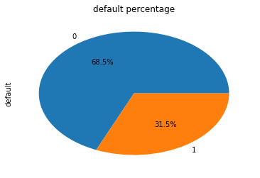

```python
loan_ana['default'].value_counts().plot(kind = 'pie', autopct = '%1.1f%%');
plt.title('default percentage')
```

> From the pie chart of loan excluding the current status, 68.5% were completed and 31.5% were default

```python
loan_ana['borrowerrate'].describe()
```

```
count    48949.000000
mean         0.203111
std          0.082599
min          0.000000
25%          0.135500
50%          0.198000
75%          0.269900
max          0.360000
Name: borrowerrate, dtype: float64
```

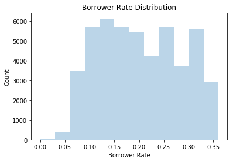

```python
# univariate plots of column borrowerrate
base_color = sb.color_palette()[0]
bins = np.arange(0, loan_ana['borrowerrate'].max() + 0.01, 0.03);
plt.hist(data = loan_ana, x = 'borrowerrate', bins = bins, alpha = 0.3, color = base_color);
plt.title('Borrower Rate Distribution');
plt.xlabel('Borrower Rate');
plt.ylabel('Count');
```

```python
# univariate plots of prosperrating_(alpha)
prosperrating_cat = ['unknown', 'HR', 'E', 'D', 'C', 'B', 'A', 'AA']
loan_ana['prosperrating_(alpha)'] = pd.Categorical(loan_ana['prosperrating_(alpha)'], categories = prosperrating_cat, ordered = True)
```

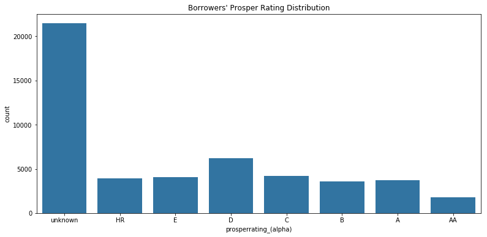

```python
plt.subplots(figsize = (13, 6))
sb.countplot(data = loan_ana, x = 'prosperrating_(alpha)', color = base_color);
plt.title("Borrowers' Prosper Rating Distribution");
```

> There's a lot of data on the unknown row, this should be as a result of the inaccuracy of data from before July 2009. I will ignore that for now.

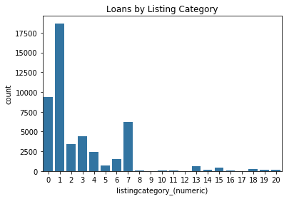

```python
# univariate plots of listingcategory_(numeric)
sb.countplot(data = loan_ana, x = 'listingcategory_(numeric)', color = base_color);
plt.title('Loans by Listing Category');
```

> Certain categories have more loans, with the highest count on category 1

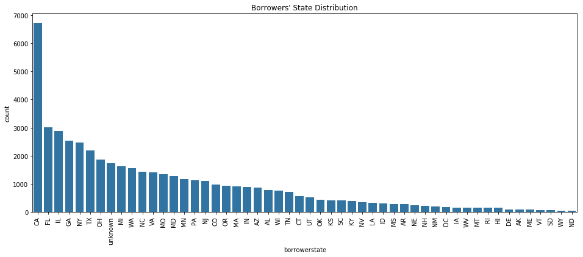

```python
# Univariate plots of borrowerstate
state_order = loan_ana['borrowerstate'].value_counts().index
plt.subplots(figsize = (16, 6));
sb.countplot(data = loan_ana, x = 'borrowerstate', color = base_color, order = state_order);
plt.xticks(rotation = 90);
plt.title("Borrowers' State Distribution");
```

> The highest number of borrowers are from california as per the borrower's state distribution.

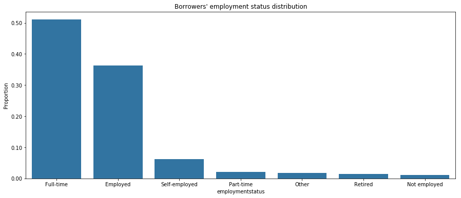

```python
# Let's analyze the employmentstatus variable
type_counts = loan_ana['employmentstatus'].value_counts()
type_order = type_counts.index
n_emp = loan_ana['employmentstatus'].value_counts().sum()
max_type_count = type_counts[0]
max_propn = max_type_count / n_emp
tick_props = np.arange(0, max_propn, 0.1)
tick_names = ['{:0.2f}'.format(v) for v in tick_props]
plt.subplots(figsize = (15, 6))
base_color = sb.color_palette()[0]
sb.countplot(data = loan_ana, x = 'employmentstatus', color = base_color, order = type_order);
plt.yticks(tick_props * n_emp, tick_names);
plt.ylabel('Proportion');
plt.title("Borrowers' employment status distribution");
```

> From the chart, we deduce that most of the borrowers have jobs. A very small percentage of borrowers are either retired and unemployed, with the highest proportion of borrowers having full time jobs

```python
# Check the values in incomerange
loan_ana['incomerange'].unique()
```

```
array(['$25,000-49,999', '$1-24,999', '$50,000-74,999', '$75,000-99,999',
       '$100,000+', 'Not employed', '$0', 'Not displayed'], dtype=object)
```

```python
# univariate plots of incomerange
income_classes = ['Not employed', 'Not displayed', '$0', '$1-24,999', '$25,000-49,999', '$50,000-74,999', '$75,000-99,999', '$100,000+']
loan_ana['incomerange'] = pd.Categorical(loan_ana['incomerange'], categories = income_classes, ordered = True)
```

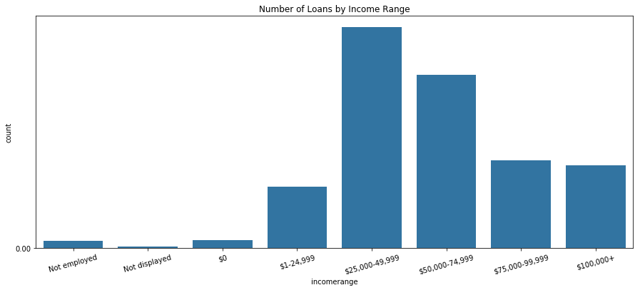

```python
income_counts = loan_ana['incomerange'].value_counts()
n_income = loan_ana['incomerange'].value_counts().sum()
max_income_count = income_counts[0]
max_prop_income = max_income_count / n_income
tick_props = np.arange(0, max_prop_income, 0.1)
tick_names = ['{:0.2f}'.format(v) for v in tick_props]
plt.subplots(figsize = (15, 6))
base_color = sb.color_palette()[0]
sb.countplot(data = loan_ana, x = 'incomerange', color = base_color);
plt.yticks(tick_props * n_income, tick_names)
plt.xticks(rotation = 15);
plt.title('Number of Loans by Income Range');
```

> From the chart, we can see most borrowers are income earners (HAVE JOBS). This confirms the chart above. Also, we see the highest number of borrowers are found in the income range \$25,000 - \\$$49,999.

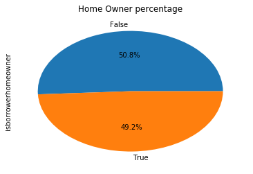

```python
# Let's find out the percentage of borrowers who are home owners
loan_ana['isborrowerhomeowner'].value_counts().plot(kind = 'pie', autopct = '%1.1f%%');
plt.title('Home Owner percentage');
```

> There is a 50%:50% difference between the borrowers that are home owners and that don't have homes.

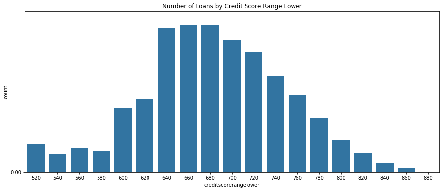

```python
# Let's analyze the credit score
credit_counts = loan_ana['creditscorerangelower'].value_counts()
n_credit = loan_ana['creditscorerangelower'].value_counts().sum()
max_credit_count = income_counts[0]
max_prop_credit = max_credit_count / n_credit
tick_props = np.arange(0, max_prop_credit, 0.025)
tick_names = ['{:0.2f}'.format(v) for v in tick_props]
loan_ana['creditscorerangelower'] = loan_ana['creditscorerangelower'].apply(int)
plt.subplots(figsize = (15, 6))
sb.countplot(data = loan_ana, x = 'creditscorerangelower', color = base_color)
plt.yticks(tick_props * n_income, tick_names);
plt.title('Number of Loans by Credit Score Range Lower')
plt.ylim(0, 6500);
```

> Credit score range is more concentrated between 640 - 720, very few borrowers have credit score lower than 580.

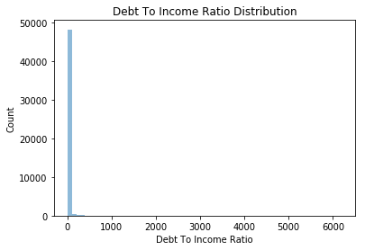

```python
# univariate plots of debttoincomeratio
bins = np.arange(0, loan_ana['debttoincomeratio'].max() + 1, 100);
plt.hist(data = loan_ana, x = 'debttoincomeratio', bins = bins, alpha = 0.5);
plt.title('Debt To Income Ratio Distribution');
plt.xlabel('Debt To Income Ratio');
plt.ylabel('Count');
```

> Debt to Income Ratio Distrib. is very skewed so I will have to transform it using the log transformation method

```python
loan_ana['debttoincomeratio'].describe()
```

```
count    48949.000000
mean         5.711041
std         57.857881
min          0.000000
25%          0.120000
50%          0.200000
75%          0.310000
max       6291.865167
Name: debttoincomeratio, dtype: float64
```

```python
np.log10(loan_ana['debttoincomeratio'].describe())
```

```
count    4.689744
mean     0.756715
std      1.762363
min          -inf
25%     -0.920819
50%     -0.698970
75%     -0.508638
max      3.798779
Name: debttoincomeratio, dtype: float64
```

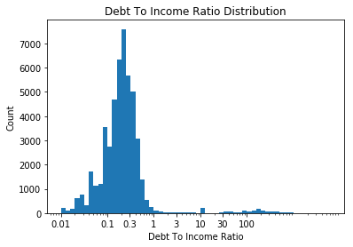

```python
# Plot a chart with debttoincomeratio > 0 here.
bins = 10 ** np.arange(-2, 3.8 + 0.1, 0.1)
ticks = [0.01, 0.1, 0.3, 1, 3, 10, 30, 100]
labels = ['{}'.format(v) for v in ticks]
plt.hist(data = loan_ana, x = 'debttoincomeratio', bins = bins);
plt.xscale('log');
plt.xticks(ticks, labels);
plt.title('Debt To Income Ratio Distribution');
plt.xlabel('Debt To Income Ratio');
plt.ylabel('Count');
```

> Most of the borrowers have debt to income ratio in range (0, 1), some have the ratio even higher than 100.

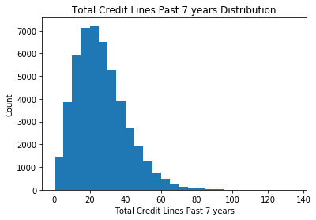

```python
# univariate plots of totalcreditlinespast7years
bins = np.arange(0, loan_ana['totalcreditlinespast7years'].max() + 1, 5);
plt.hist(data = loan_ana, x = 'totalcreditlinespast7years', bins = bins);
plt.title('Total Credit Lines Past 7 years Distribution');
plt.xlabel('Total Credit Lines Past 7 years');
plt.ylabel('Count');
```

> Seems kind of skewed, let's do some transformation as well.

```python
np.log(loan_ana['totalcreditlinespast7years'].describe())
```

```
count    10.798534
mean      3.249056
std       2.658270
min       0.693147
25%       2.708050
50%       3.178054
75%       3.526361
max       4.912655
Name: totalcreditlinespast7years, dtype: float64
```

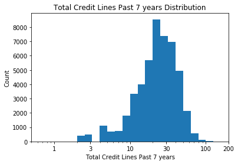

```python
bins = 10 ** np.arange(0, 4.9 + 0.1, 0.1)
ticks = [1, 3, 10, 30, 100, 200]
labels = ['{}'.format(v) for v in ticks]
plt.hist(data = loan_ana, x = 'totalcreditlinespast7years', bins = bins);
plt.xscale('log');
plt.xticks(ticks, labels);
plt.xlim(0.5, 200);
plt.title('Total Credit Lines Past 7 years Distribution');
plt.xlabel('Total Credit Lines Past 7 years');
plt.ylabel('Count');
```

> Many of the borrowers have credit lines between 10 and 50.

<a id = 'bivariate'></a>

## Bivariate Exploration

> Let's start by exploring income and borrower rate.

#### Is income correlated with borrower rate?

```
$25,000-49,999    16826
$50,000-74,999    13184
$75,000-99,999     6681
$100,000+          6299
$1-24,999          4668
$0                  607
Not employed        546
Not displayed       138
Name: incomerange, dtype: int64
```

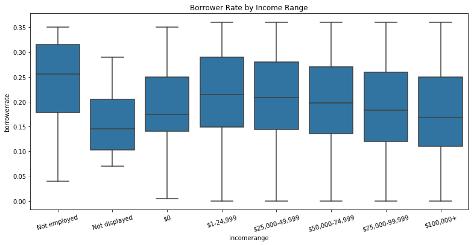

```python
plt.subplots(figsize = (13, 6));
sb.boxplot(data = loan_ana, x = 'incomerange', y = 'borrowerrate', color = base_color);
plt.xticks(rotation = 15);
plt.title('Borrower Rate by Income Range');
print(income_counts)
```

> When income > 1, we notice that the average borrower rate tends to go down as imcome range goes up. Also, the not employed group tends to have higher borrowerate than any other groups, logically, this makes sense. But we now see that Not displayed & \$0 groups have relatively lowest borrowerrate than other groups. Probably because the sample size of 'not displayed' is quite little, only 138 rows. But this doesn't explain why \\$0 has low borrowerrate.

#### Is default correlated with borrowerrate?

```
Text(0.5,1,'Borrower Rate by Default State')
```

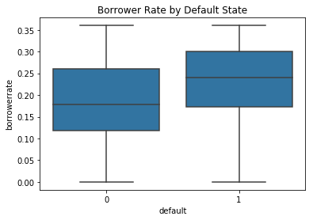

```python
sb.boxplot(data = loan_ana, x = 'default', y = 'borrowerrate', color = base_color);
plt.title('Borrower Rate by Default State')
```

> Looks like borrowerrate is higher in the default group, what could be the cause?

#### Is credit score correlated with borrower rate?

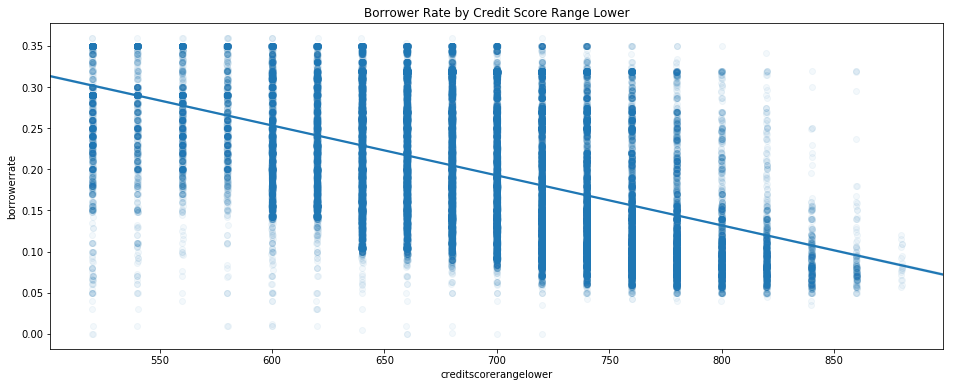

```python
plt.figure(figsize = (16, 6))
sb.regplot(data = loan_ana, x = 'creditscorerangelower', y = 'borrowerrate', truncate = False, x_jitter = 0.3, scatter_kws={'alpha':1/20});
plt.xlabel('creditscorerangelower')
plt.ylabel('borrowerrate');
plt.title('Borrower Rate by Credit Score Range Lower');
```

> The borrowerrate does seem to have a correlation with credit score range lower! There is a negative correlation between these two variables.

#### Which income group has most defaults?

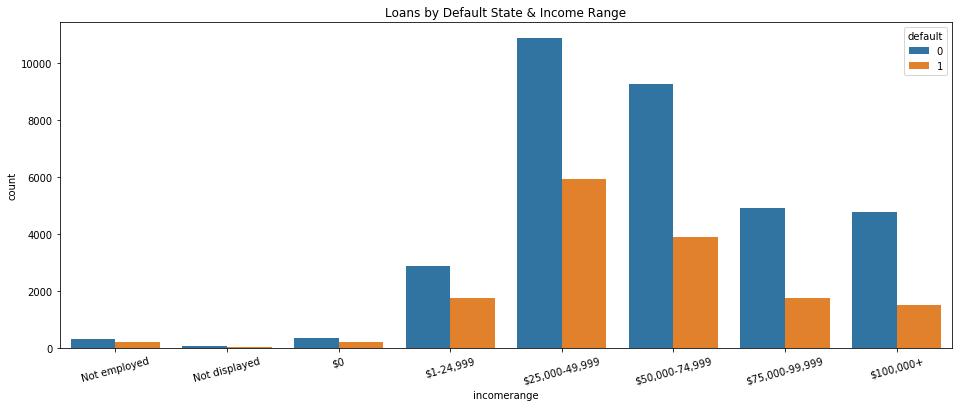

```python
# Let's look at correlation between incomerange and default too.
plt.subplots(figsize = (16, 6))
sb.countplot(data = loan_ana, x = 'incomerange', hue = 'default');
plt.xticks(rotation = 15);
plt.title('Loans by Default State & Income Range');
```

> From the graph above, we can know that more defaulted loans came from the \$25,000 - \\$49,999 range. But how about the default rate? Let's calculate the default rate of each income range.

#### Which income group has the highest default rate?

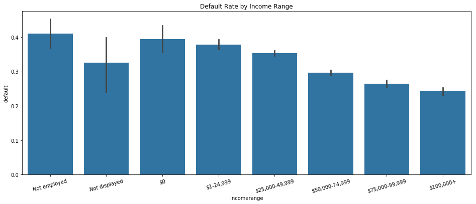

```python
plt.figure(figsize = (16, 6))
sb.barplot(data = loan_ana, x = 'incomerange', y = 'default', color = base_color);
plt.xticks(rotation = 15);
plt.title('Default Rate by Income Range');
```

#### Do certain loan categories have higher default rate?

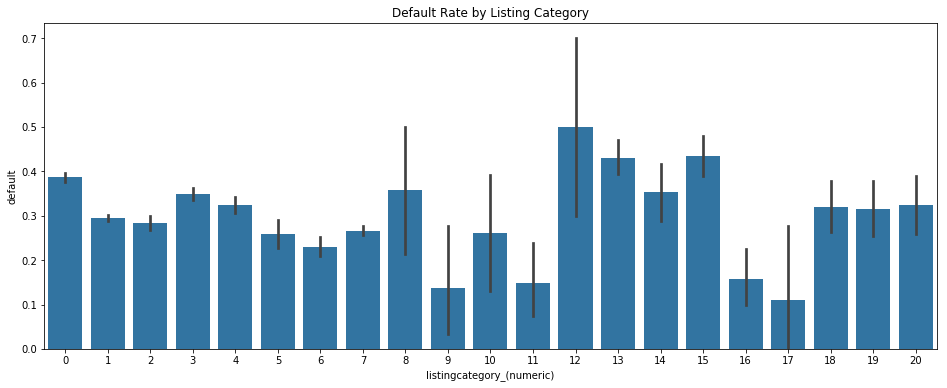

```python
plt.subplots(figsize = (16, 6))
sb.barplot(data = loan_ana, x = 'listingcategory_(numeric)', y = 'default', color = base_color);
plt.title('Default Rate by Listing Category');
```

> Some type of loans do have a higher default rate averagely.

#### Is there any different between default rate across states?

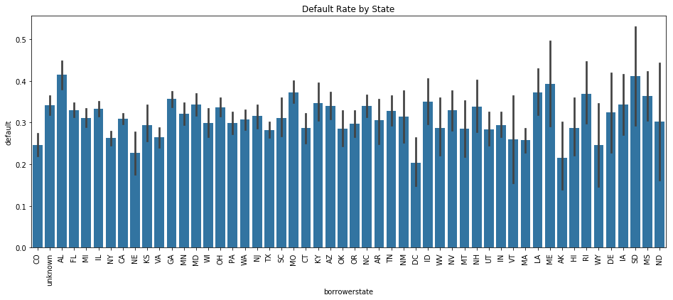

```python
plt.subplots(figsize = (16, 6))
sb.barplot(data = loan_ana, x = 'borrowerstate', y = 'default', color = base_color);
plt.xticks(rotation = 90);
plt.title('Default Rate by State');
```

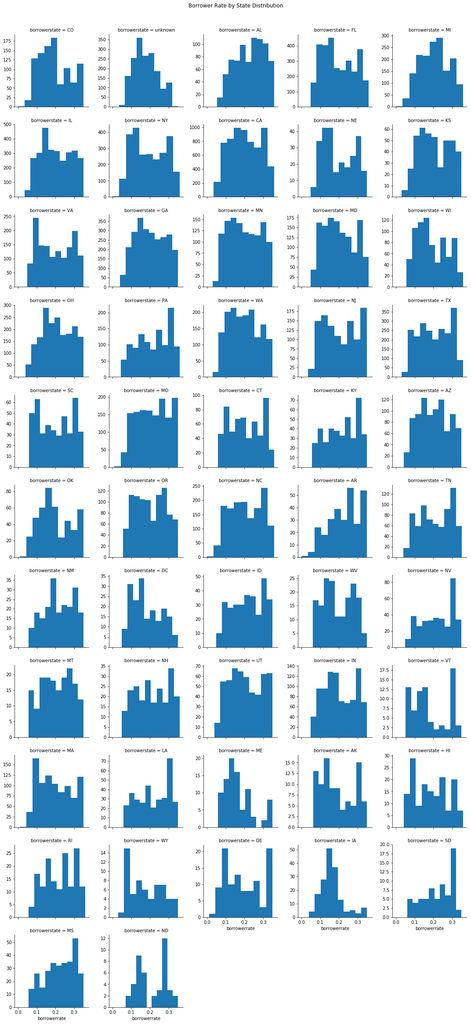

```python
g = sb.FacetGrid(data = loan_ana, col = 'borrowerstate', col_wrap=5, sharey=False)
g.map(plt.hist, 'borrowerrate');
g.fig.subplots_adjust(top = 0.95);
g.fig.suptitle('Borrower Rate by State Distribution');
```

#### Is there any correlation between homeowner and default rate?

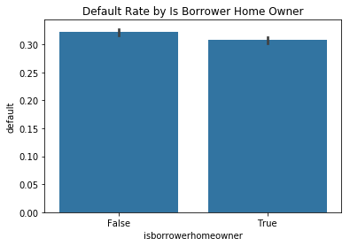

```python
sb.barplot(data = loan_ana, x = 'isborrowerhomeowner', y = 'default', color = base_color);
plt.title('Default Rate by Is Borrower Home Owner');
```

> There is a very little difference between default rate and home owner

#### Is there a correlation between credit score lower range and default rate?

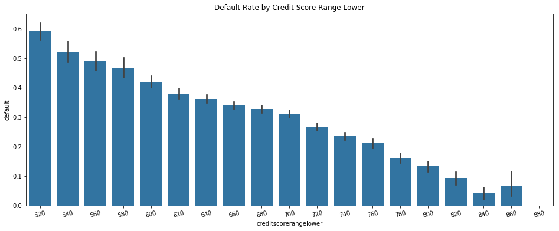

```python
plt.subplots(figsize = (16, 6))
sb.barplot(data = loan_ana, x = 'creditscorerangelower', y = 'default', color = base_color);
plt.xticks(rotation = 15);
plt.title('Default Rate by Credit Score Range Lower');
```

The is a strong negative correlation between credit score lower range and default rate. However, there is an anomally at creditscorerangelower = 860

<a id = 'multivariate'></a>

## Multivariate Exploration

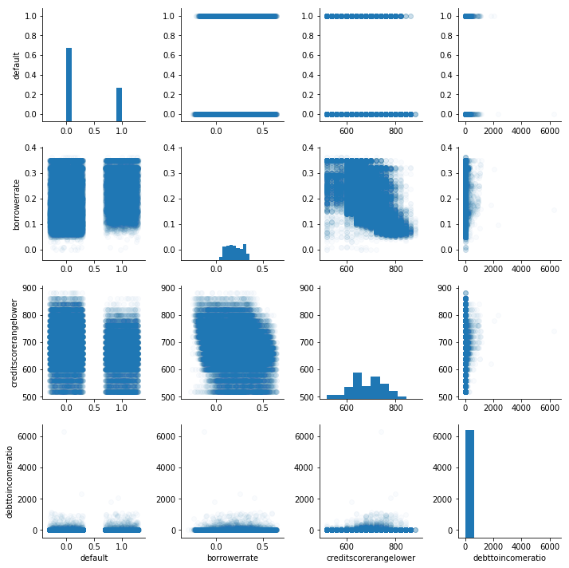

```python
g = sb.PairGrid(data = loan_ana, vars = ['default', 'borrowerrate', 'creditscorerangelower', \
                                              'debttoincomeratio'])
g.map_diag(plt.hist)
g.map_offdiag(sb.regplot, truncate = False, x_jitter = 0.3, scatter_kws = {'alpha': 1/40}, fit_reg = False);
```

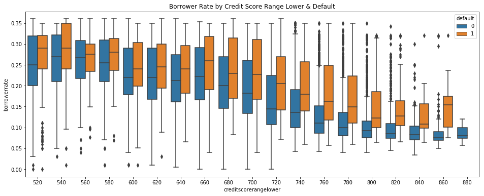

```python
plt.figure(figsize = (16, 6))
sb.boxplot(data = loan_ana, x = 'creditscorerangelower', y = 'borrowerrate', hue = 'default');
plt.title('Borrower Rate by Credit Score Range Lower & Default');
```

> From the graph, for each credit score, the borrower rate for the default group are more likely to be higher.

[figure not shown]

```python
g = sb.FacetGrid(data = loan_ana, col = 'creditscorerangelower', col_wrap = 3);
g.map(sb.regplot, 'default', 'delinquencieslast7years', x_jitter = 0.1, scatter_kws = {'alpha': 1/5});
g.fig.subplots_adjust(top = 0.95);
g.fig.suptitle('Debt to Income Ratio by Default State by Credit Score Range Lower');
```

> There's not much difference between these two groups in terms of delinquencies in the last 7 years.

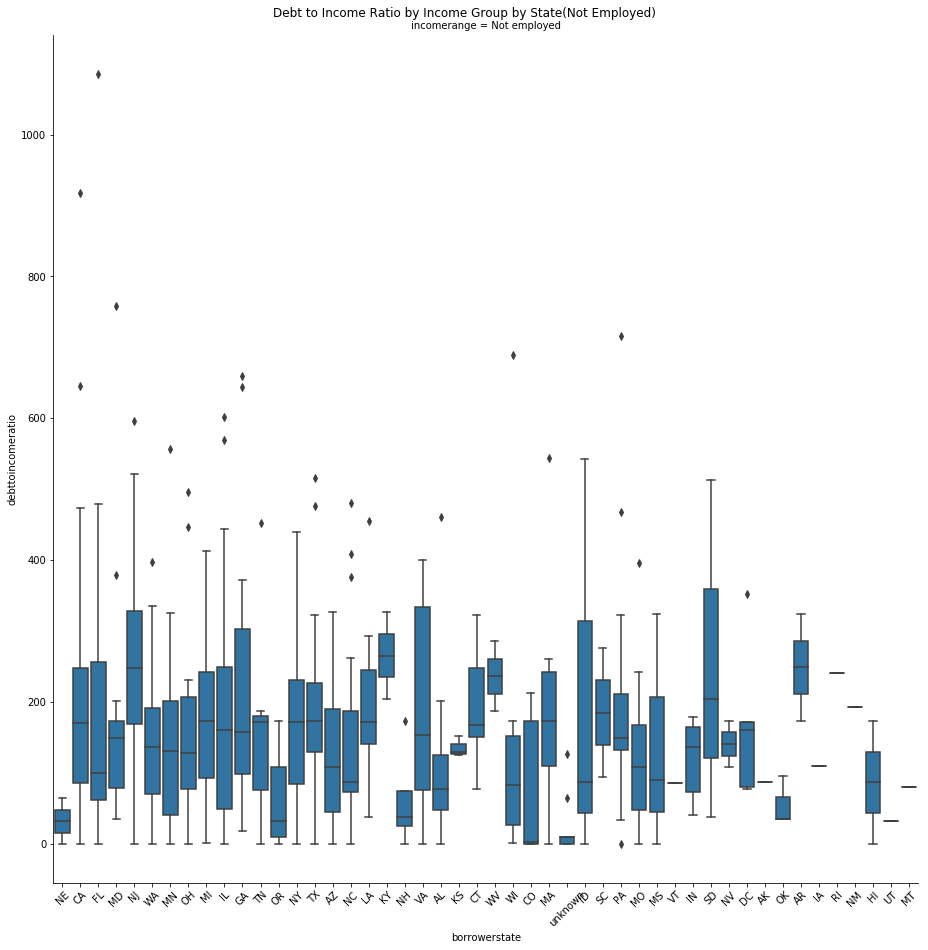

```python
# Group Not Employed
no_salary = loan_ana.loc[loan_ana['incomerange'].isin(['Not employed']), ['incomerange', 'borrowerstate', 'debttoincomeratio']]
no_salary['incomerange'] = no_salary['incomerange'].astype(str)
g = sb.FacetGrid(data = no_salary, col = 'incomerange', col_wrap = 1, size = 13, sharey = False, margin_titles = True);
g.map(sb.boxplot, 'borrowerstate', 'debttoincomeratio');
plt.xticks(rotation = 45);
g.fig.subplots_adjust(top = 0.95);
g.fig.suptitle('Debt to Income Ratio by Income Group by State(Not Employed)');
```

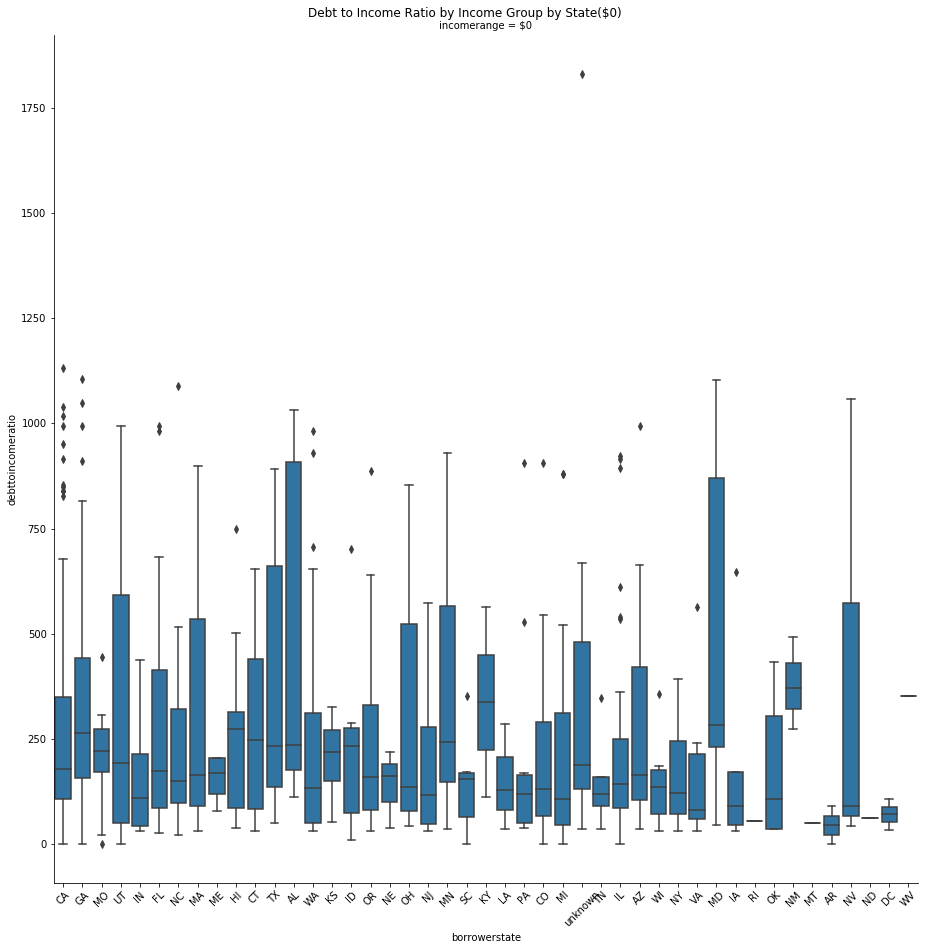

```python
# Group Not $0
no_salary = loan_ana.loc[loan_ana['incomerange'].isin(['$0']), ['incomerange', 'borrowerstate', 'debttoincomeratio']]
no_salary['incomerange'] = no_salary['incomerange'].astype(str)
g = sb.FacetGrid(data = no_salary, col = 'incomerange', col_wrap = 1, size = 13, sharey = False, margin_titles = True);
g.map(sb.boxplot, 'borrowerstate', 'debttoincomeratio');
plt.xticks(rotation = 45);
g.fig.subplots_adjust(top = 0.95);
g.fig.suptitle('Debt to Income Ratio by Income Group by State($0)');
```

<a id = 'conclusion'></a>

## Conclusion

#### Reference:

https://github.com/yduan004/communicate-data-loan-data-from-Prosper

https://github.com/yabiola/udacity-data-analyst/tree/main/Project%203%20-%20Prosper%20Loan/Project-3%20Prosper%20Loan

https://stackoverflow.com/questions/21090316/plotting-pandas-dataframes-in-to-pie-charts-using-matplotlib

https://stackoverflow.com/questions/61908745/error-astype-got-an-unexpected-keyword-argument-categories

https://github.com/topics/explanatory-data-analysis?o=desc&s=forks

https://pandas.pydata.org/pandas-docs/stable/reference/api/pandas.DataFrame.select_dtypes.html